# nb_05_Salifort_Motors_project_Feature_Engineering

**Navigation** Home Project Home **Analyst's Notebooks**

EDA Cleanse - .ipynb EDA Analysis - .ipynb Feature Engineering - .ipynb

**ML Models**

Logistical Regression - .ipynb Decision Tree - .ipynb XGBoost - .ipynb Random Forest - .ipynb Model Comparisons - .ipynb Model Demonstration - .ipynb

**Client Documentation**

Client Proposal - Docs PACE Plan Analyst's Summary Executive Summary PRESENTATION Executive Summary Analysis HR Summary PRESENTATION HR Summary Analysis Team Summary Generator Notebook Team Summary example Project Close

# Salifort Motors - Feature Engineering

### Document Information

| Document Title | Salifort Motors Feature Engineering |
| --- | --- |
| Author | Rod Slater |
| Version | 1.0 |
| Created | 01-11-2023 |
| Modified | 16-11-2023 |

### Client Details

| Client Name | Salifort Motors |
| --- | --- |
| Client Contact | Mr HR Team |
| Client Email | hr@salifortmotors.it |
| Client Project | HR Team Data Driven Solutions from Machine Learning Models |

### Document Overview

Feature Engineering for HR Data provided by Salifort Motors. This notebook details the feature engineering carried out on the provided data.

- Salifort Motors - Feature Engineering
  - Document Information
  - Client Details
  - Document Overview
- Table of contents
  - Initialise Notebook
    - Import Packages
    - Set Pandas Options
    - Initialise Notebook Options
    - Import data
  - Gather information about the data
    - Describe the dataframe
    - Check for missing values
    - Check for duplicates
    - Check Categorical values for consistency
- Feature Engineering
  - Encode categorical values 'dept' as dummies
  - Feature Engineer continuous values `avg_mnth_hrs` to binary `overworked`
  - Correlation Heatmap (full)
  - Correlation Heatmap (Focus)
  - Discard problematic columns
    - `accident`
  - Save the Feature Engineered dataframe
    - Focus Features
  - Save the Focus Features dataframe

## Initialise Notebook

### Import Packages

```python
# Import packages

# Data manipulation
import numpy as np
import pandas as pd

# Data visualization
import matplotlib.pyplot as plt
import seaborn as sns


# Data modelling Imports
from xgboost import XGBClassifier, XGBRegressor, plot_importance

from sklearn.linear_model import LogisticRegression
from sklearn.tree import DecisionTreeClassifier
from sklearn.ensemble import RandomForestClassifier

# For metrics and helpful functions
from sklearn.model_selection import GridSearchCV, train_test_split
from sklearn.metrics import accuracy_score, precision_score, recall_score,\
f1_score, confusion_matrix, ConfusionMatrixDisplay, classification_report
from sklearn import metrics
from sklearn.metrics import roc_auc_score, roc_curve
from sklearn.tree import plot_tree
from sklearn.preprocessing import StandardScaler

import statsmodels.api as sm

# For saving models
import pickle
```

### Set Pandas Options

```python
# set Pandas Display Options
pd.options.display.float_format = '{:.2f}'.format
pd.set_option('display.precision', 2)
pd.set_option('display.max_columns', None)
pd.set_option('display.width', 120)
```

### Initialise Notebook Options

```python
load_path = "/home/hass/Documents/Learning/Salifort-Motors-Capstone-Project/00-data_cleaned/"
save_path = "/home/hass/Documents/Learning/Salifort-Motors-Capstone-Project/00-data_cleaned/"
```

### Import data

```python
# Load cleaned dataset, with outliers removed, into a dataframe
df1 = pd.read_csv(load_path + "data_cleaned_NoOl_NoFE_AllFeat.csv")

df1.info()
```

```
<class 'pandas.core.frame.DataFrame'>
RangeIndex: 11167 entries, 0 to 11166
Data columns (total 10 columns):
 #   Column          Non-Null Count  Dtype
---  ------          --------------  -----
 0   satisfaction    11167 non-null  float64
 1   last_eval       11167 non-null  float64
 2   number_project  11167 non-null  float64
 3   avg_mnth_hrs    11167 non-null  float64
 4   tenure          11167 non-null  float64
 5   accident        11167 non-null  float64
 6   left            11167 non-null  float64
 7   promotion       11167 non-null  float64
 8   dept            11167 non-null  object
 9   salary          11167 non-null  object
dtypes: float64(8), object(2)
memory usage: 872.6+ KB
```

## Gather information about the data

### Describe the dataframe

```python
# Assuming you have a DataFrame named 'df'
summary = df1.describe(include='all')

# Additional summary information
info = df1.info()

# Combine summary statistics and information
summary_info = pd.concat([summary, info], axis=0)

summary_info
```

```
<class 'pandas.core.frame.DataFrame'>
RangeIndex: 11167 entries, 0 to 11166
Data columns (total 10 columns):
 #   Column          Non-Null Count  Dtype
---  ------          --------------  -----
 0   satisfaction    11167 non-null  float64
 1   last_eval       11167 non-null  float64
 2   number_project  11167 non-null  float64
 3   avg_mnth_hrs    11167 non-null  float64
 4   tenure          11167 non-null  float64
 5   accident        11167 non-null  float64
 6   left            11167 non-null  float64
 7   promotion       11167 non-null  float64
 8   dept            11167 non-null  object
 9   salary          11167 non-null  object
dtypes: float64(8), object(2)
memory usage: 872.6+ KB
```

|  | satisfaction | last_eval | number_project | avg_mnth_hrs | tenure | accident | left | promotion | dept | salary |
| --- | --- | --- | --- | --- | --- | --- | --- | --- | --- | --- |
| count | 11167.00 | 11167.00 | 11167.00 | 11167.00 | 11167.00 | 11167.00 | 11167.00 | 11167.00 | 11167 | 11167 |
| unique | NaN | NaN | NaN | NaN | NaN | NaN | NaN | NaN | 10 | 3 |
| top | NaN | NaN | NaN | NaN | NaN | NaN | NaN | NaN | sales | low |
| freq | NaN | NaN | NaN | NaN | NaN | NaN | NaN | NaN | 2997 | 5429 |
| mean | 0.63 | 0.72 | 3.79 | 200.14 | 3.11 | 0.15 | 0.17 | 0.01 | NaN | NaN |
| std | 0.24 | 0.17 | 1.16 | 48.56 | 0.90 | 0.36 | 0.37 | 0.12 | NaN | NaN |
| min | 0.09 | 0.36 | 2.00 | 96.00 | 2.00 | 0.00 | 0.00 | 0.00 | NaN | NaN |
| 25% | 0.49 | 0.57 | 3.00 | 157.00 | 2.00 | 0.00 | 0.00 | 0.00 | NaN | NaN |
| 50% | 0.66 | 0.72 | 4.00 | 199.00 | 3.00 | 0.00 | 0.00 | 0.00 | NaN | NaN |
| 75% | 0.82 | 0.86 | 5.00 | 243.00 | 4.00 | 0.00 | 0.00 | 0.00 | NaN | NaN |
| max | 1.00 | 1.00 | 7.00 | 310.00 | 5.00 | 1.00 | 1.00 | 1.00 | NaN | NaN |

```python
df1.dtypes
```

```
satisfaction      float64
last_eval         float64
number_project    float64
avg_mnth_hrs      float64
tenure            float64
accident          float64
left              float64
promotion         float64
dept               object
salary             object
dtype: object
```

### Check for missing values

```python
df1.isna().sum()
```

```
satisfaction      0
last_eval         0
number_project    0
avg_mnth_hrs      0
tenure            0
accident          0
left              0
promotion         0
dept              0
salary            0
dtype: int64
```

### Check for duplicates

```python
df1.duplicated().sum()
```

```
0
```

### Check Categorical values for consistency

```python
print(df1['salary'].unique())
print(df1['dept'].unique())
```

```
['low' 'medium' 'high']
['sales' 'accounting' 'hr' 'technical' 'support' 'management' 'it'
 'product_mng' 'marketing' 'randd']
```

# Feature Engineering

```python
# Encode salary as an ordinal numeric rather than get_dummies.
# The data is ordinal and we want to preserve that, encoding dummies would
# add three additional dimension and we want to avoid large dimension models

df1['salary'] = (
    df1['salary'].astype('category')
    .cat.set_categories(['low', 'medium', 'high'])
    .cat.codes
)
```

### Encode categorical values 'dept' as dummies

```python
# One Hot Encode dept
df1 = pd.get_dummies(df1, columns = ['dept'])
df1.dtypes
```

```
satisfaction        float64
last_eval           float64
number_project      float64
avg_mnth_hrs        float64
tenure              float64
accident            float64
left                float64
promotion           float64
salary                 int8
dept_accounting        bool
dept_hr                bool
dept_it                bool
dept_management        bool
dept_marketing         bool
dept_product_mng       bool
dept_randd             bool
dept_sales             bool
dept_support           bool
dept_technical         bool
dtype: object
```

### Feature Engineer continuous values `avg_mnth_hrs` to binary `overworked`

See EDA notes, overworked threshold is set to 175 hours.

```python
pd.options.display.float_format = '{:.2f}'.format

# Create `overworked` column. For now, it's identical to average monthly hours.
df1['overworked'] = df1['avg_mnth_hrs']

# Inspect mean, max and min average monthly hours values
print('Max hours  :', df1['overworked'].max())
print('Min hours  : ', df1['overworked'].min())
print('Mean hours :', round(df1['overworked'].mean(),2))
```

```
Max hours  : 310.0
Min hours  :  96.0
Mean hours : 200.14
```

```python
# Define `overworked` as working > 175 hrs/week
df1['overworked'] = (df1['overworked'] > 175).astype(int)

# Display first few rows of new column
df1.head()
```

|  | satisfaction | last_eval | number_project | avg_mnth_hrs | tenure | accident | left | promotion | salary | dept_accounting | dept_hr | dept_it | dept_management | dept_marketing | dept_product_mng | dept_randd | dept_sales | dept_support | dept_technical | overworked |
| --- | --- | --- | --- | --- | --- | --- | --- | --- | --- | --- | --- | --- | --- | --- | --- | --- | --- | --- | --- | --- |
| 0 | 0.38 | 0.53 | 2.00 | 157.00 | 3.00 | 0.00 | 1.00 | 0.00 | 0 | False | False | False | False | False | False | False | True | False | False | 0 |
| 1 | 0.11 | 0.88 | 7.00 | 272.00 | 4.00 | 0.00 | 1.00 | 0.00 | 1 | False | False | False | False | False | False | False | True | False | False | 1 |
| 2 | 0.72 | 0.87 | 5.00 | 223.00 | 5.00 | 0.00 | 1.00 | 0.00 | 0 | False | False | False | False | False | False | False | True | False | False | 1 |
| 3 | 0.37 | 0.52 | 2.00 | 159.00 | 3.00 | 0.00 | 1.00 | 0.00 | 0 | False | False | False | False | False | False | False | True | False | False | 0 |
| 4 | 0.41 | 0.50 | 2.00 | 153.00 | 3.00 | 0.00 | 1.00 | 0.00 | 0 | False | False | False | False | False | False | False | True | False | False | 0 |

```python
# Drop the `average_monthly_hours` column
df1 = df1.drop('avg_mnth_hrs', axis=1)

# Display first few rows of resulting dataframe
df1.head()
```

|  | satisfaction | last_eval | number_project | tenure | accident | left | promotion | salary | dept_accounting | dept_hr | dept_it | dept_management | dept_marketing | dept_product_mng | dept_randd | dept_sales | dept_support | dept_technical | overworked |
| --- | --- | --- | --- | --- | --- | --- | --- | --- | --- | --- | --- | --- | --- | --- | --- | --- | --- | --- | --- |
| 0 | 0.38 | 0.53 | 2.00 | 3.00 | 0.00 | 1.00 | 0.00 | 0 | False | False | False | False | False | False | False | True | False | False | 0 |
| 1 | 0.11 | 0.88 | 7.00 | 4.00 | 0.00 | 1.00 | 0.00 | 1 | False | False | False | False | False | False | False | True | False | False | 1 |
| 2 | 0.72 | 0.87 | 5.00 | 5.00 | 0.00 | 1.00 | 0.00 | 0 | False | False | False | False | False | False | False | True | False | False | 1 |
| 3 | 0.37 | 0.52 | 2.00 | 3.00 | 0.00 | 1.00 | 0.00 | 0 | False | False | False | False | False | False | False | True | False | False | 0 |
| 4 | 0.41 | 0.50 | 2.00 | 3.00 | 0.00 | 1.00 | 0.00 | 0 | False | False | False | False | False | False | False | True | False | False | 0 |

### Correlation Heatmap (full)

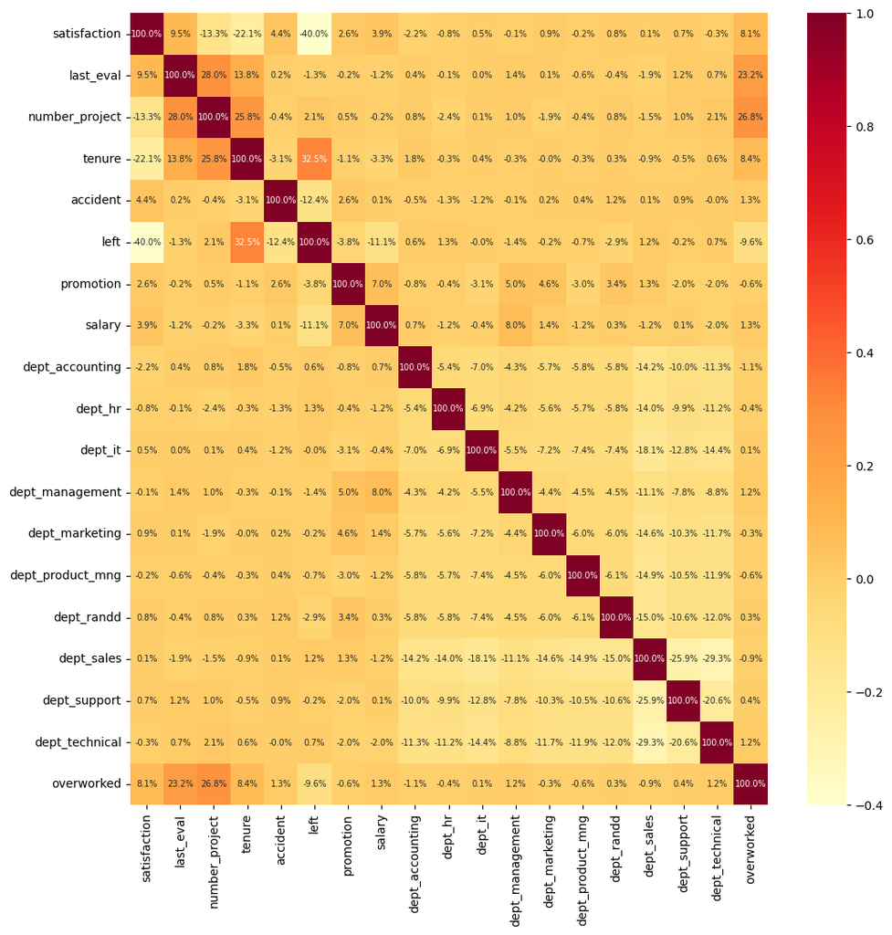

```python
## Correlation Heatmap

df_corr = df1.corr() #.sort_values(by = 'left', ascending = False)

plt.figure(figsize = (12,12))
sns.heatmap(df_corr, annot=True, annot_kws={"size": 7}, fmt='.1%', cmap='YlOrRd')
```

### Correlation Heatmap (Focus)

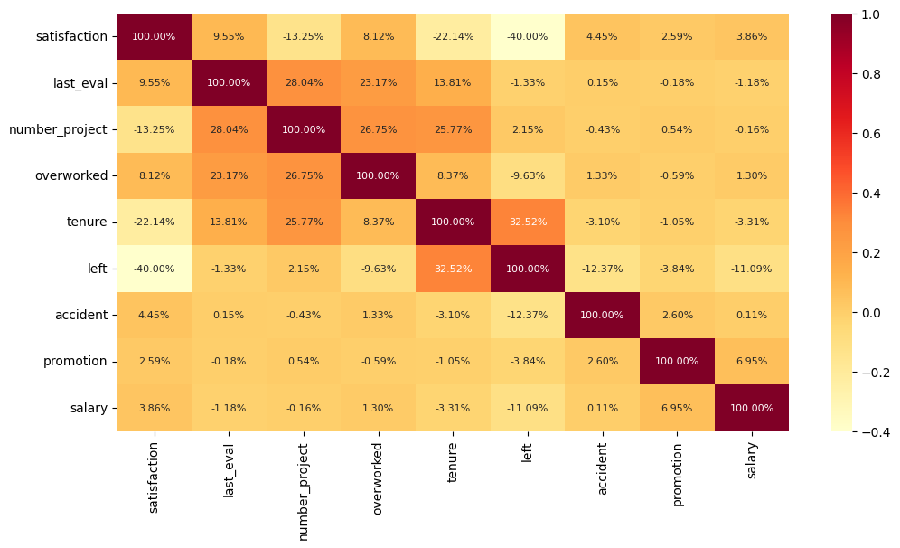

```python
## Focus on features with higher correlation values:
df_corr = df1[['satisfaction', 'last_eval', 'number_project', 'overworked',
               'tenure', 'left', 'accident','promotion', 'salary']]
df_corr = df_corr.corr() #.sort_values(by = 'left', ascending = False)

plt.figure(figsize = (12,6))
sns.heatmap(df_corr, annot=True, annot_kws={"size": 8}, fmt='.2%', cmap='YlOrRd')
```

### Discard problematic columns

#### `accident`

`Accident` seems very high compared to the national average (See EDA) This require further investigation.

```python
# Drop `accident` and save resulting dataframe in new variable
df1.drop(['accident'], axis=1, inplace=True)

# Display first few rows of new dataframe
df1.columns
```

```
Index(['satisfaction', 'last_eval', 'number_project', 'tenure', 'left', 'promotion', 'salary', 'dept_accounting',
       'dept_hr', 'dept_it', 'dept_management', 'dept_marketing', 'dept_product_mng', 'dept_randd', 'dept_sales',
       'dept_support', 'dept_technical', 'overworked'],
      dtype='object')
```

## Save the Feature Engineered dataframe

```python
# Required for the XGBoost modelling
df1.to_csv(save_path+'data_cleaned_NoOl_FE_AllFeat.csv', index=False) # Feature Engineered on avg_mnth_hrs, salary, dept
df1.columns
```

```
Index(['satisfaction', 'last_eval', 'number_project', 'tenure', 'left', 'promotion', 'salary', 'dept_accounting',
       'dept_hr', 'dept_it', 'dept_management', 'dept_marketing', 'dept_product_mng', 'dept_randd', 'dept_sales',
       'dept_support', 'dept_technical', 'overworked'],
      dtype='object')
```

### Focus Features

Remove the departments from the model data so we can compare how they perform

Remove `accident`

```python
df2 = df1[['satisfaction', 'last_eval', 'number_project', 'overworked', 'tenure', 'left', 'promotion', 'salary']]
```

## Save the Focus Features dataframe

Excludes departments which appear to have a low correlation

```python
# Feature Engineered on avg_mnth_hrs, salary.
# dept REMOVED
df2.to_csv(save_path + 'data_cleaned_NoOl_FE_NoDept.csv', index = False)
df2.columns
```

```
Index(['satisfaction', 'last_eval', 'number_project', 'overworked', 'tenure', 'left', 'promotion', 'salary'], dtype='object')
```